# STAT340 HW03: Testing I

Svadrut Kukunooru

October 2022

## Instructions

Update the “author” and “date” fields in the header and complete the exercises below. Knit the document, and submit **both the HTML and RMD** files to Canvas.

**Due date:** October 6, 2022 at 11:59pm.

## 1) Permutation testing

Below are data arising from a (fictionalized) data source: the number of defects per day on an assembly line before (`before`) and after (`after`) installation of a new torque converter (this is a totally fictional “part” of an assembly line– just treat these as “control” and “treatment” groups, respectively).

```r
before <- c(2, 3, 8, 3, 4, 5, 6, 3, 5, 5, 2, 4, 3, 5, 4, 1, 3, 5, 8, 4, 4, 2, 2, 4, 6, 3, 4, 3, 4, 6, 5, 4, 5, 4, 6, 6, 3, 7, 0, 6);
after <- c(1, 4, 2, 3, 6, 2, 5, 7, 3, 5, 3, 2, 6, 5, 3, 2, 6, 4, 4, 3, 4, 5, 2, 7, 2, 2, 8, 2, 7, 5 );
```

1. Use a permutation test to assess the claim that installation of the new part changed the prevalence of defects. That is, test the null hypothesis that the distribution of defects is the same before and after installation of the new part.

**Hint:** be careful of the fact that these two different groups have different sizes!

**Note:** You do not *have* to produce a p-value, here, though that would be a very reasonable thing to do!

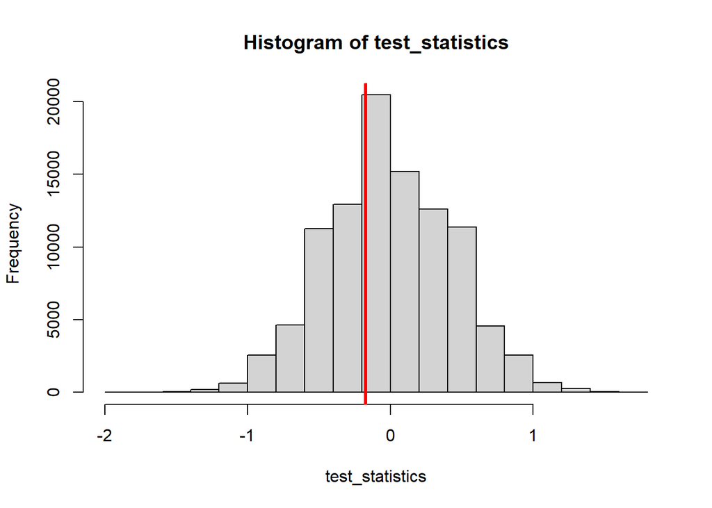

```r
# TODO: code goes here.

# Assume that the null hypothesis is that the distribution of defects is the same before and after installation of the new part.

# Therefore, we must assume that the null hypothesis is true, and work with the assumption that the distributions are the same.

# If the distributions are the same, this means that each distribution has an equal probability of having defects.

permute_and_compute <- function( ctrl_data, trmt_data ) {
  # ctrl_data and trmt_data are vectors storing our control and treatment data
  # We are going to pretend that these two data sets came from the same
  # distribution. That means
  # 1) pooling them and randomly reassigning them
  #     to the treatment and control groups.
  # and then
  # 2) Computing our test statistic (the difference in means) on that
  #     new "version" of the data.

  # Pool the data
  pooled_data <- c( ctrl_data, trmt_data );
  # Randomly shuffle the data and assign it to control and treatment groups.
  n_ctrl <- length( ctrl_data );
  n_trmt <- length( trmt_data );
  n_total <- n_ctrl + n_trmt;
  # Now, let's shuffle the data, and assign the first n_ctrl elements
  # to the control group, and the rest to the treatment group.
  # We're going to do this using the sample() function.
  # To randomly shuffle the data, it's enough to sample from the
  # original data (i.e., the pooled data) WITHOUT replacement.
  # The result is that shuffled_data contains the same elements as
  # pooled_data, just in a (random) different order.
  shuffled_data <- sample( pooled_data, size=n_total, replace=FALSE );
  # Now, the first n_ctrl of these data points are our new control group
  # and the remaining elements are assigned to our treatment group.
  shuffled_ctrl <- shuffled_data[1:n_ctrl];
  shuffled_trmt <- shuffled_data[(n_ctrl+1):n_total];
  # Okay, last step: compute the difference in means of our two samples.
  return( mean(shuffled_trmt)-mean(shuffled_ctrl) );
}

NMC <- 1e5; # Might want to increase this to more like 1e5 for better accuracy
test_statistics <- rep( 0, NMC ); # Vector to store our "fake" test statistics

# Now, NMC times, shuffle the data, recompute the test statistic, and record.
for(i in 1:NMC ) {
  test_statistics[i] <- permute_and_compute( before, after );
}

# Now, let's make a histogram of those permuted test statistics.
hist( test_statistics )
abline( v=mean(after)-mean(before), lw=3, col='red')
```

2. Explain, briefly, what you did above and why. Imagine that you are trying to explain to someone who isn’t your statistics professor what exactly you are doing in a permutation test. Explain your conclusion based on your test above. Three to five sentences should be plenty, but you are free to write as much or as little as you think is necessary to clearly explain your findings.

Assuming that the null hypothesis is true, the distribution of both groups are identical. This means that if the values in each group are randomly pooled and placed in two groups, the distributions will be the same. I made a histogram of this and compared the average to the original average between the two files. Since these were similar, we do not reject the null hypothesis.